# Week 8 Class Notes

## Announcement

- Office hours update:
  - Mondays 11am - noon (316 Thomas)
  - Tuesdays 3pm - **4pm** (330 Thomas)
  - Wednesdays 2:30pm - **4pm** (316 Thomas)
  - **Thursdays 3:30pm - 4:30pm (330 Thomas)**
  - Fridays 11am - noon (316 Thomas)
- Feel free to use office hours as a chance to just meet with your group and work together with an expert nearby if needed.
- Homework Solutions, Activity Examples, & R Cheat Sheets: “Canvas >> Files”

## Building Graphics

1. Draw (by hand) or imagine the specific plot that you intend to construct
2. Data Wrangling (if needed) - get the data in glyph-ready form, or verify that the current form is glyph-ready for your purposes.
3. Establish the frame using a `ggplot()` statement
4. Create the intended glyph using `geom_[style]()` such as
   - `geom_point()`
   - `geom_bar()`
   - `geom_boxplot()`
   - `geom_density()`
   - `geom_vline()`
   - `geom_segment()`
   - `geom_histogram()`
   - `geom_ash()`
   - and *many* more
5. Map variables to the graphical attributes of the glyph using `aes( )`
6. Add additional layers to the frame using the `+` symbol

## Want some help?

This can all be a lot to keep straight… visit “Canvas >> Files >> Cheatsheets”" for some resources to help you shoulder the burden:

- [EnoughDCF](http://dtkaplan.github.io/DCF-2014/CourseNotes/Guides/EnoughDCF.pdf): one page summary from the author of Data Computing
- [rstudio-ggplot2-cheatsheet](https://www.rstudio.com/wp-content/uploads/2015/12/ggplot2-cheatsheet-2.0.pdf): 2 page summary of `ggplot2` tools and usage from RStudio
- [rstudio-data-wrangling-cheatsheet](https://www.rstudio.com/wp-content/uploads/2015/02/data-wrangling-cheatsheet.pdf): 2 page summary of `dplyr` (& `tidyr`) tools and usage from RStudio

Also see…

- [rstudio-rmarkdown-cheatsheet](https://www.rstudio.com/wp-content/uploads/2016/03/rmarkdown-cheatsheet-2.0.pdf)
- [rstudio-rmarkdown-reference](https://www.rstudio.com/wp-content/uploads/2015/03/rmarkdown-reference.pdf)
- [rstudio-IDE-cheatsheet](https://www.rstudio.com/wp-content/uploads/2016/01/rstudio-IDE-cheatsheet.pdf)
- [and more…](https://www.rstudio.com/resources/cheatsheets/)

## Remarks about `facet_wrap()`

The syntax for facets can be a bit complicated for new users. Here are a few pointers:

- `facet_wrap()` just makes a box for each level of the categorical variable
  - Syntax: `facet_wrap( ~ categoricalVariable)`
  - For example:

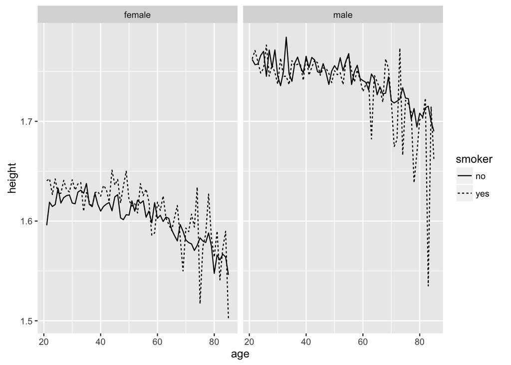

```r
data("NCHS")

# 1is.na(smoker) gets cases that are non-missing for `smoker` (i.e. removes NA's)
Heights <-
  NCHS %>%
  filter(age > 20, !is.na(smoker)) %>%
  group_by(sex, smoker, age) %>%
  summarise(height = mean(height, na.rm = TRUE))

Heights %>%
  ggplot(aes(x = age, y = height)) +
  geom_line(aes(linetype = smoker)) +
  facet_wrap( ~ sex)
```

## Remarks about `facet_grid()`

- `facet_grid()` allows control of row & column facets
- `facet_grid()` syntax:
  - row & column facets: `facet_grid(rows ~ cols)`
  - row facets only: `facet_grid( rows ~ . )` (note the required “`.`”)
  - column facets only: `facet_grid( ~ cols)` (no “`.`” this time)

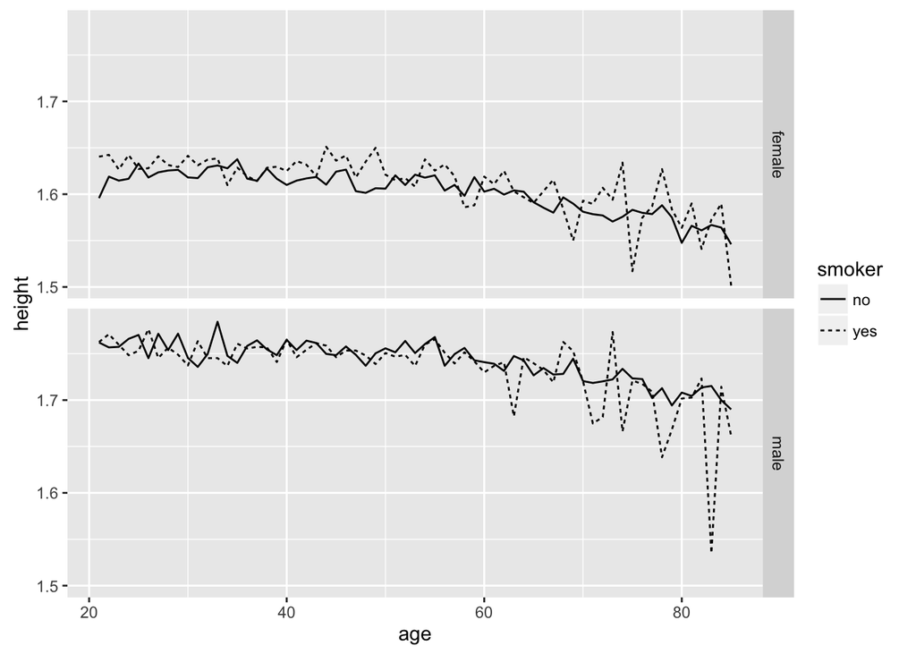

```r
Heights %>%
  ggplot(aes(x = age, y = height)) +
  geom_line(aes(linetype = smoker)) +
  facet_grid(sex ~ .)
```

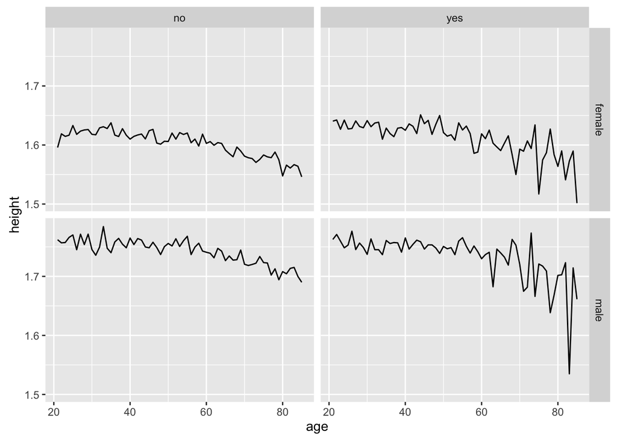

```r
Heights %>%
  ggplot(aes(x = age, y = height)) +
  geom_line() +
  facet_grid(sex ~ smoker)
```

## Homework

- Activity: Bicycle Sharing (DC p. 182)
  - Sections A.3 & A.5 are worth extra credit (not required)
  - Make sure you complete all the “your turn” segments in A.1, A.2, A.4
  - The last “your turn (optional)” at the end of A.2 is **required**
- **Homework**:
  - DC Ch 8 Exercises: 8.1, 8.2, 8.3 (skip the world map)
  - DC chapter 11 reading quiz on Canvas

## Activity: Bicycle Sharing (DC p. 182)

Assignment is worth a total of 10 points.

- [2 point] Turn in HTML with embedded .Rmd file (e.g. “DataComputing simple” template)
- [2 points] A.1 side-by-side boxplots of rental durations
- [4 points total] A.2 plots
  - [0.5 point] density plot: day of the year (1 to 365)
  - [0.5 point] density plot: day of the week (Sunday to Saturday; numeric is fine)
  - [0.5 point] density plot: hour of the day (0 to 24)
  - [0.5 point] density plot: minute in the hour (0 to 60)
  - [1 points] Plot rental frequency by hour, weekday, & client type
  - [1 points] Plot rental density by hour, weekday, & client type
- [2 points] A.4 leaflet
- [**EXTRA CREDIT**: 2 pts] complete both A.3 & A.5
- General Remarks:
  - Sections A.3 & A.5 are worth extra credit (not required)
  - Make sure you complete all the “your turn” segments in A.1, A.2, A.4
  - The last “your turn (optional)” at the end of A.2 is **REQUIRED**

[teaching](https://mdbeckman.github.io/Teaching.html) | [stat 184 home](https://mdbeckman.github.io/Teaching/AY2016-17/stat184/stat184-fall2016.html) | [syllabus](https://mdbeckman.github.io/Teaching/AY2016-17/stat184/stat184-syllabus.html) | [piazza](https://piazza.com/psu/fall2016/stat184/home) | [canvas](https://psu.instructure.com/courses/1792768)